# Water Quality in North Carolina: Nutrients and Specific Conductance

Peggy Chen

2024-06-28

# R Markdown

Using the USGS “dataRetrieval” package to plot the frequency of measuring certain chemicals across North Carolina.

Paramter codes, or PCodes, are dependent on the chemical or physical factor being tested. For a list of the codes, go to: https://help.waterdata.usgs.gov/code/parameter_cd_query?fmt=rdb&group_cd=NUT&inline=true

Need help? Type into the console: HASP::explore_site()

### Loading and prepping data

```r
library(tidyverse)
library(remotes)
library(HASP)
```

```r
library(dataRetrieval)
library(dplyr)
library(ggplot2)
library(sf)
library(remotes)
library(HASP)
```

### Plotting total nitrogen testing sites across NC

Note that total nitrogen in this plot is defined as nitrate, nitrite, ammonia, organic-N, and is tested in water, unfiltered, and measured in milligrams per liter.

```r
# What sites measured nitrogen in North Carolina?
nitrogen_sites <- whatNWISsites(stateCd = "NC",
                          parameterCd = "00600")
nrow(nitrogen_sites)
```

```
## [1] 795
```

```r
# Identify these sites
names(nitrogen_sites)
```

```
## [1] "agency_cd"   "site_no"     "station_nm"  "site_tp_cd"  "dec_lat_va"
## [6] "dec_long_va" "colocated"   "queryTime"
```

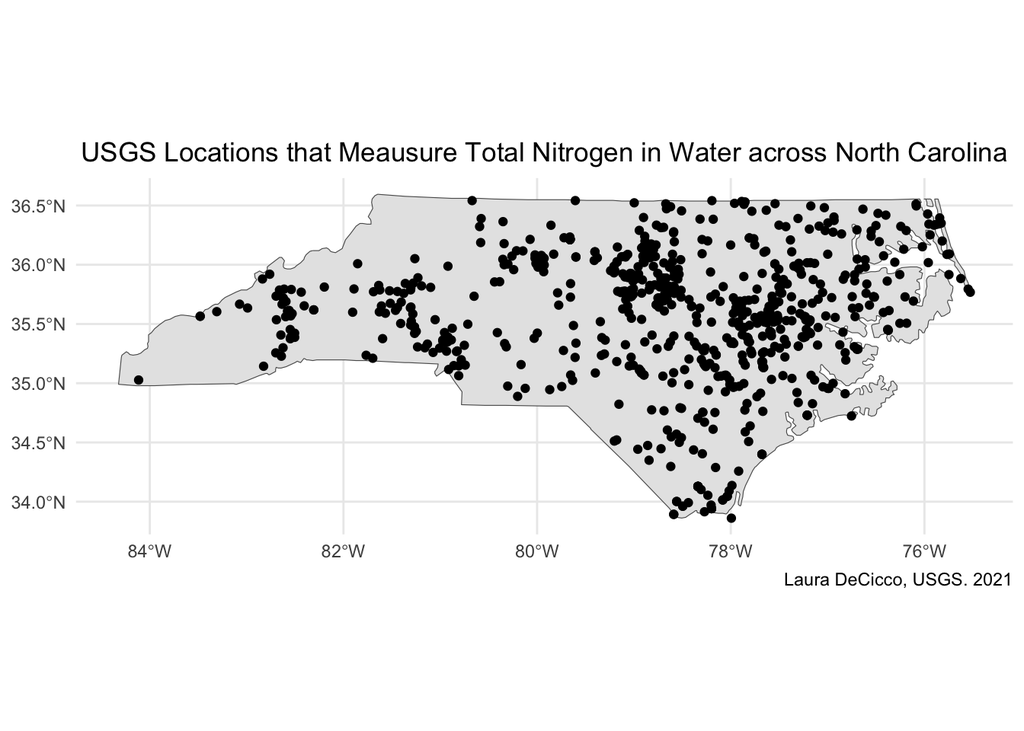

```r
# Plot the locations of these sites
usa <- st_as_sf(maps::map("state", fill=TRUE, plot =FALSE),
                crs = 4269)

sf_nitrogen <- st_as_sf(nitrogen_sites,
                  coords = c("dec_long_va", "dec_lat_va"),
                  crs = 4269)

# Bad map :(
ggplot() +
  geom_sf(data = usa[ usa$ID == "north carolina" ,]) +
  geom_sf(data = sf_nitrogen) +
  xlab(NULL)+
  ylab(NULL)+
  theme_minimal() +
  theme(plot.title = element_text(hjust = 0.5),
        plot.subtitle = element_text(hjust = 0.5)) +
  labs(title = "USGS Locations that Meausure Total Nitrogen in Water across North Carolina",
       caption = "Laura DeCicco, USGS. 2021")
```

### Plotting ammonia testing sites across NC

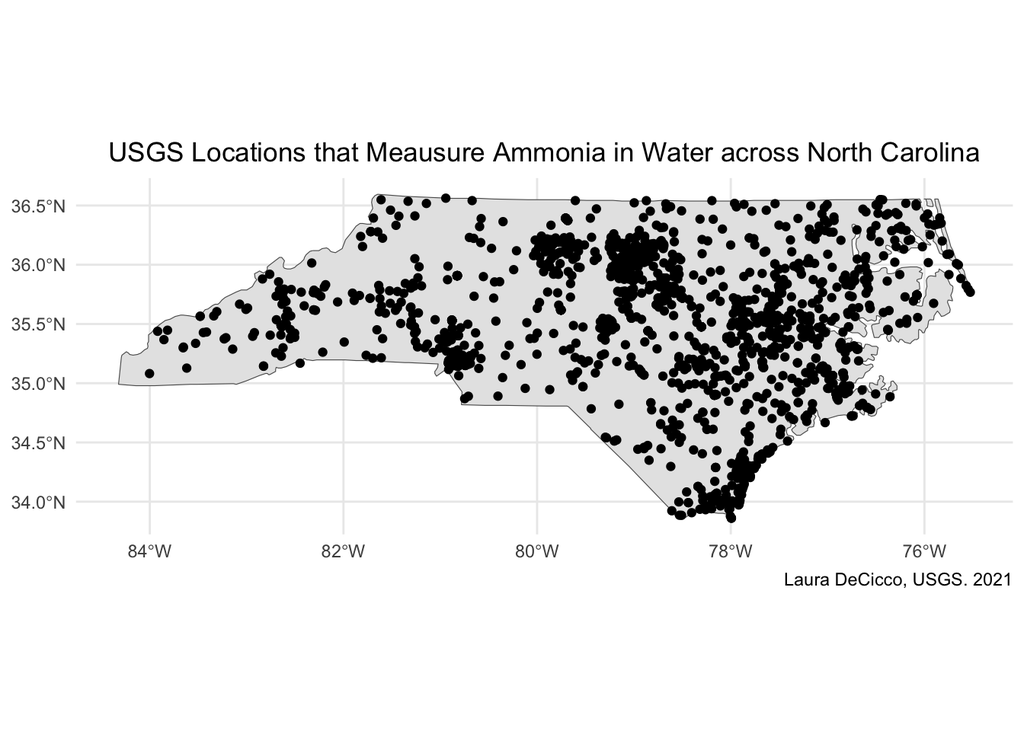

```r
ammonia_sites <- whatNWISsites(stateCd = "NC",
                          parameterCd = "00608")
usa <- st_as_sf(maps::map("state", fill=TRUE, plot =FALSE),
                crs = 4269)
sf_ammonia <- st_as_sf(ammonia_sites,
                  coords = c("dec_long_va", "dec_lat_va"),
                  crs = 4269)
ggplot() +
  geom_sf(data = usa[ usa$ID == "north carolina" ,]) +
  geom_sf(data = sf_ammonia) +
  xlab(NULL)+
  ylab(NULL)+
  theme_minimal() +
  theme(plot.title = element_text(hjust = 0.5),
        plot.subtitle = element_text(hjust = 0.5)) +
  labs(title = "USGS Locations that Meausure Ammonia in Water across North Carolina",
       caption = "Laura DeCicco, USGS. 2021")
```

### Plotting phosphate freq across state

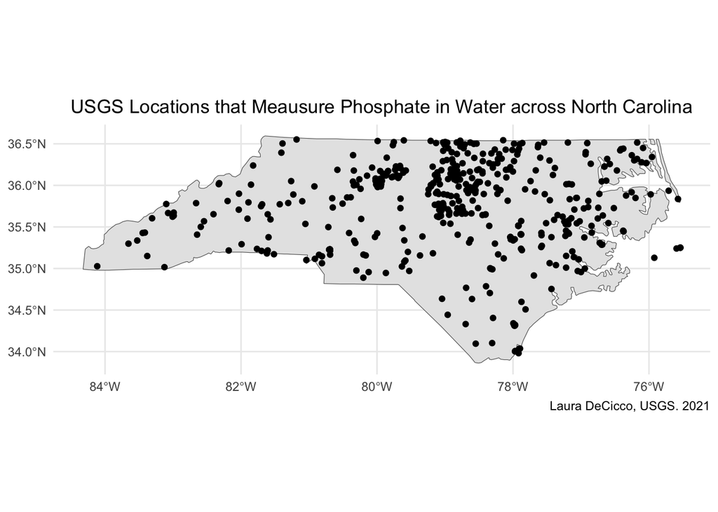

```r
phosphate_site <- whatNWISsites(stateCd = "NC",
                               parameterCd = "00650")
usa <- st_as_sf(maps::map("state", fill=TRUE, plot =FALSE),
                crs = 4269)
sf_phosphate <- st_as_sf(phosphate_site,
                       coords = c("dec_long_va", "dec_lat_va"),
                       crs = 4269)
ggplot() +
  geom_sf(data = usa[ usa$ID == "north carolina" ,]) +
  geom_sf(data = sf_phosphate) +
  xlab(NULL)+
  ylab(NULL)+
  theme_minimal() +
  theme(plot.title = element_text(hjust = 0.5),
        plot.subtitle = element_text(hjust = 0.5)) +
  labs(title = "USGS Locations that Meausure Phosphate in Water across North Carolina",
       caption = "Laura DeCicco, USGS. 2021")
```

### Field Specific Conductance freq across NC Map

Specific conductance, water, unfiltered, field, microsiemens per centimeter at 25 degrees.

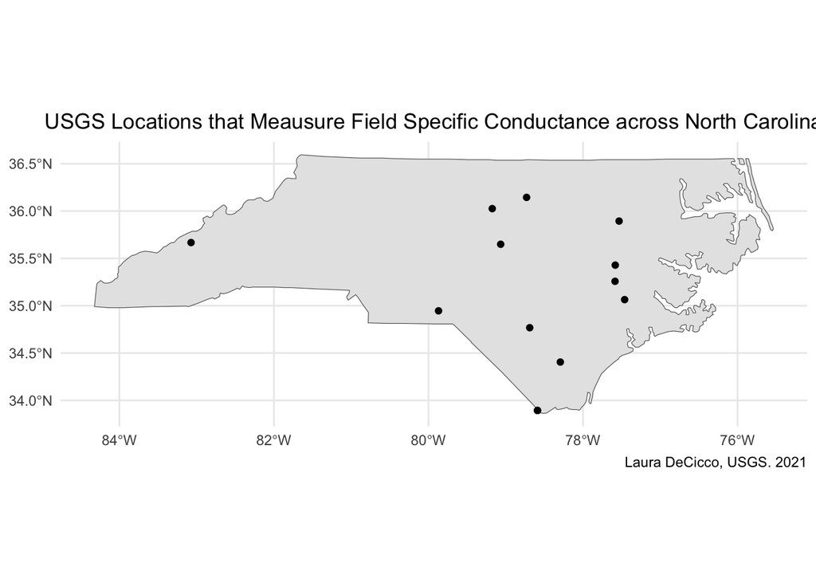

```r
conductivity_sites <- whatNWISsites(stateCd = "NC",
                          parameterCd = "00094")
usa <- st_as_sf(maps::map("state", fill=TRUE, plot =FALSE),
                crs = 4269)
sf_conductivity <- st_as_sf(conductivity_sites,
                  coords = c("dec_long_va", "dec_lat_va"),
                  crs = 4269)
ggplot() +
  geom_sf(data = usa[ usa$ID == "north carolina" ,]) +
  geom_sf(data = sf_conductivity) +
  xlab(NULL)+
  ylab(NULL)+
  theme_minimal() +
  theme(plot.title = element_text(hjust = 0.5),
        plot.subtitle = element_text(hjust = 0.5)) +
  labs(title = "USGS Locations that Meausure Field Specific Conductance across North Carolina",
       caption = "Laura DeCicco, USGS. 2021")
```

### Non-field SC in NC Map

Specific conductance, water, unfiltered, microsiemens per centimeter at 25 degrees Celsius.

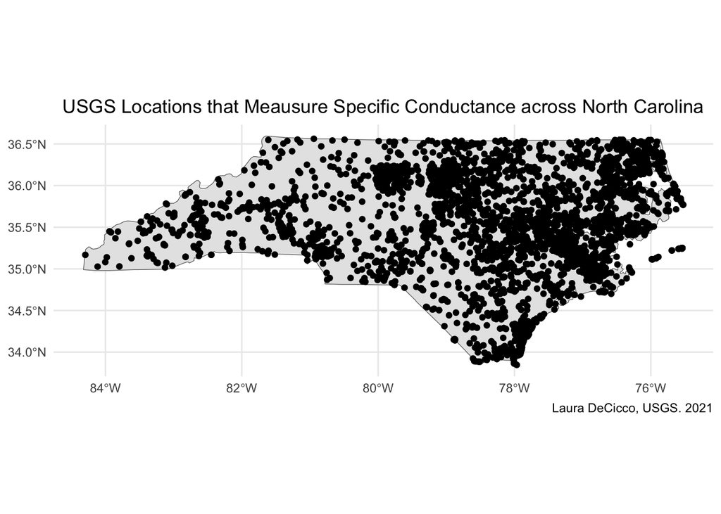

```r
conductivity_sites_2 <- whatNWISsites(stateCd = "NC",
                          parameterCd = "00095")
usa <- st_as_sf(maps::map("state", fill=TRUE, plot =FALSE),
                crs = 4269)
sf_conductivity_2 <- st_as_sf(conductivity_sites_2,
                  coords = c("dec_long_va", "dec_lat_va"),
                  crs = 4269)
ggplot() +
  geom_sf(data = usa[ usa$ID == "north carolina" ,]) +
  geom_sf(data = sf_conductivity_2) +
  xlab(NULL)+
  ylab(NULL)+
  theme_minimal() +
  theme(plot.title = element_text(hjust = 0.5),
        plot.subtitle = element_text(hjust = 0.5)) +
  labs(title = "USGS Locations that Meausure Specific Conductance across North Carolina",
       caption = "Laura DeCicco, USGS. 2021")
```

### Another SC across NC Map

Specific conductance, water, unfiltered, laboratory, microsiemens per centimeter at 25 degrees Celsius USGS use and no use by EPA. Total 25 deg C. Specific conductance uS/cm.

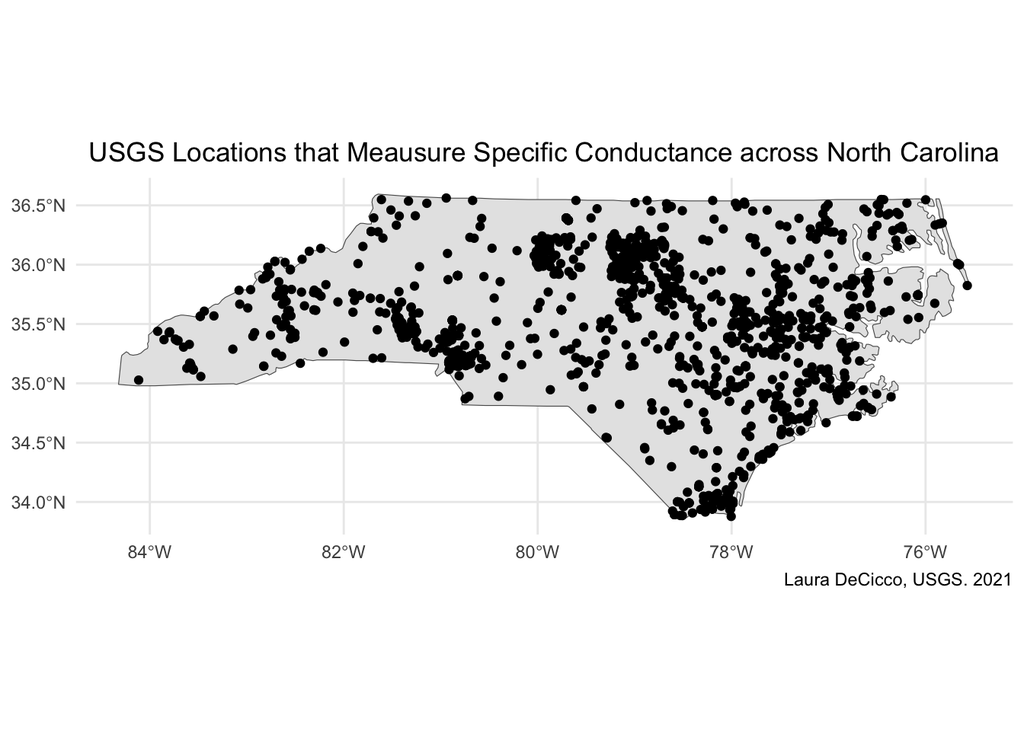

```r
conductivity_sites_3 <- whatNWISsites(stateCd = "NC",
                          parameterCd = "90095")
usa <- st_as_sf(maps::map("state", fill=TRUE, plot =FALSE),
                crs = 4269)
sf_conductivity_3 <- st_as_sf(conductivity_sites_3,
                  coords = c("dec_long_va", "dec_lat_va"),
                  crs = 4269)
ggplot() +
  geom_sf(data = usa[ usa$ID == "north carolina" ,]) +
  geom_sf(data = sf_conductivity_3) +
  xlab(NULL)+
  ylab(NULL)+
  theme_minimal() +
  theme(plot.title = element_text(hjust = 0.5),
        plot.subtitle = element_text(hjust = 0.5)) +
  labs(title = "USGS Locations that Meausure Specific Conductance across North Carolina",
       caption = "Laura DeCicco, USGS. 2021")
```

### Filtered Data Example

```r
# Assign codes and pull data
pCode <- c("00600")
phNC <- whatNWISdata(stateCd="NC",
                     parameterCd=pCode)
```

[output not shown]

```r
# Filter data acc. to freq and measurement count
phNC_1 <- phNC %>%
  filter(count_nu > 100) %>% # At least 100 measurments
  mutate(period = as.Date(end_date) - as.Date(begin_date)) %>%
  filter(period > 5*365) # At least 5x/year

nitrogen_NC_data <- readNWISqw(siteNumbers = phNC_1$site_no,
                         parameterCd = pCode)
```

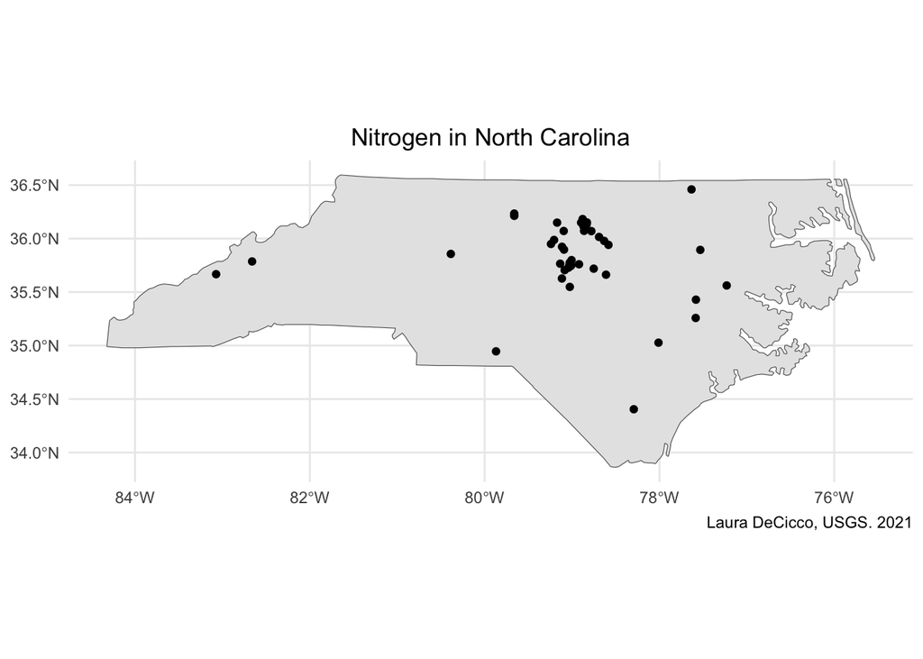

```r
# Let’s look at the maximum measured value, and number of samples
nitrogen_summary <- nitrogen_NC_data %>%
  group_by(site_no) %>%
  summarize(max = max(result_va, na.rm = TRUE),
            count = n()) %>%
  ungroup() %>%
  left_join(attr(nitrogen_NC_data, "siteInfo"),
            by = "site_no")

# Prep data to map >:(
sf_nitrogen <- st_as_sf(nitrogen_summary,
                       coords = c("dec_long_va", "dec_lat_va"),
                       crs = 4269)

# Map
plot_1 <- ggplot() +
  geom_sf(data = usa[ usa$ID == "north carolina" ,]) +
  geom_sf(data = sf_nitrogen) +
  xlab(NULL)+
  ylab(NULL)+
  theme_minimal() +
  theme(plot.title = element_text(hjust = 0.5),
        plot.subtitle = element_text(hjust = 0.5)) +
  labs(title = "Nitrogen in North Carolina",
       caption = "Laura DeCicco, USGS. 2021")
plot_1
```

### Plotting over time

These plots are measurements of specific conductance overtime, and the site codes are obtained from the “sf_conductivity” data that can be found in the environment.

```r
site <- "02129000"

qw_data <- readWQPqw(paste0("USGS-", site),
                     c("Specific conductance"))
```

[output not shown]

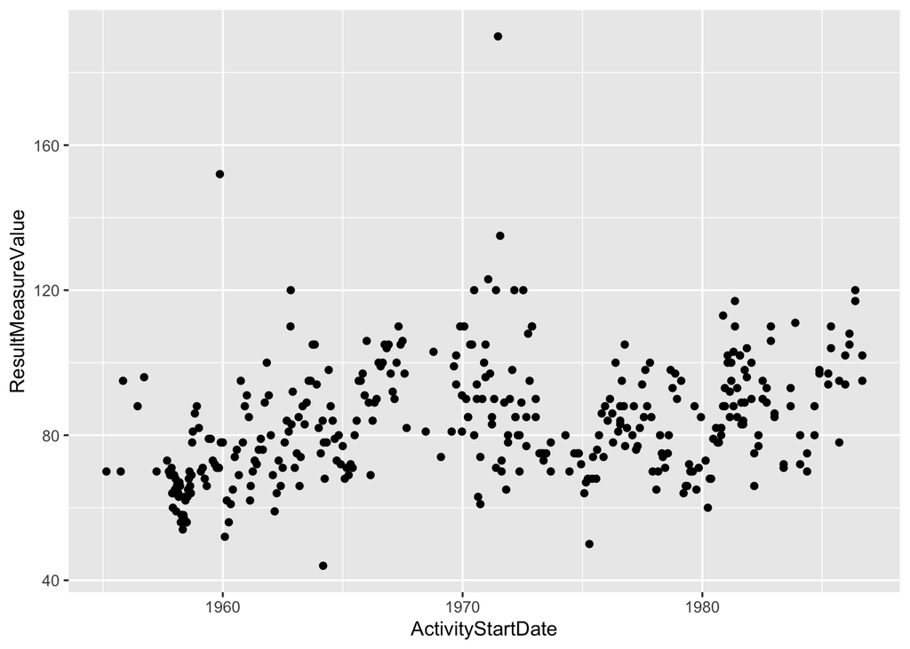

```r
plot <- ggplot(data = qw_data, aes(x = ActivityStartDate, y = ResultMeasureValue)) +
  geom_point()
plot
```

### Trying more sites

```r
site <- "02092500"

qw_data <- readWQPqw(paste0("USGS-", site),
                     c("Specific conductance"))
```

[output not shown]

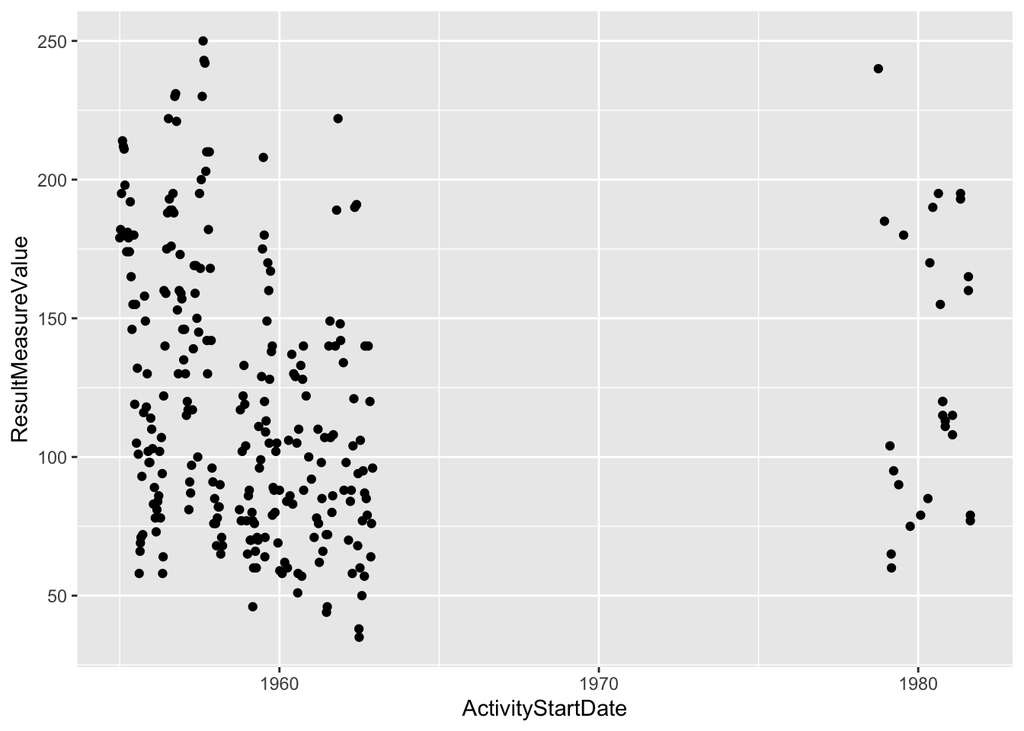

```r
plot_1 <- ggplot(data = qw_data, aes(x = ActivityStartDate, y = ResultMeasureValue)) +
  geom_point()

plot_1
```

```r
site <- "335334078352105"

qw_data <- readWQPqw(paste0("USGS-", site),
                     c("Specific conductance"))
```

[output not shown]

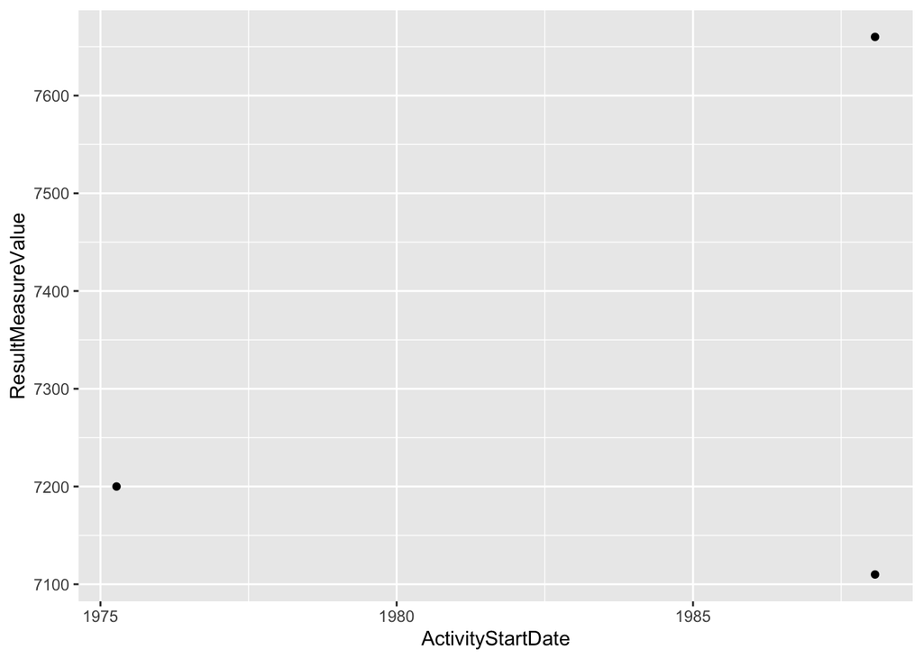

```r
plot_2 <- ggplot(data = qw_data, aes(x = ActivityStartDate, y = ResultMeasureValue)) +
  geom_point()

plot_2
```

```r
site <- "02083500"

qw_data <- readWQPqw(paste0("USGS-", site),
                     c("Specific conductance"))
```

[output not shown]

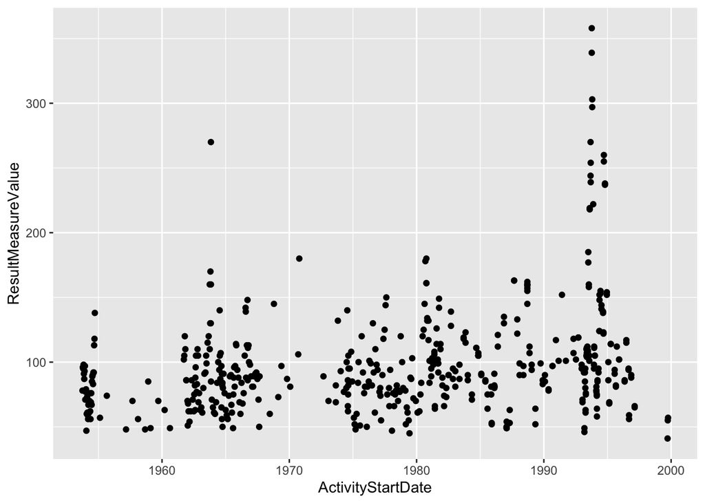

```r
plot_3 <- ggplot(data = qw_data, aes(x = ActivityStartDate, y = ResultMeasureValue)) +
  geom_point()

plot_3
```

```r
site <- "02091500"

qw_data <- readWQPqw(paste0("USGS-", site),
                     c("Specific conductance"))
```

[output not shown]

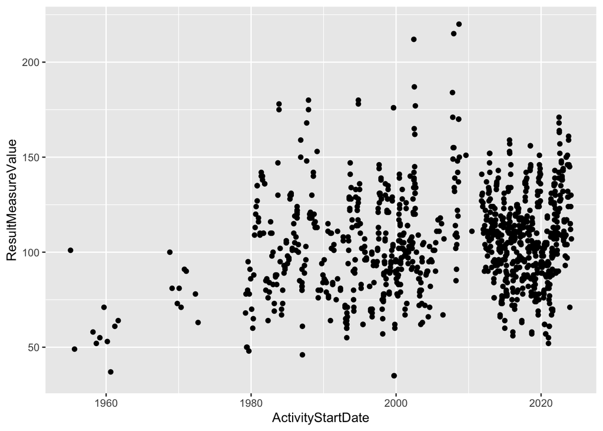

```r
plot_4 <- ggplot(data = qw_data, aes(x = ActivityStartDate, y = ResultMeasureValue)) +
  geom_point()

plot_4
```

```r
site <- "02089500"

qw_data <- readWQPqw(paste0("USGS-", site),
                     c("Specific conductance"))
```

[output not shown]

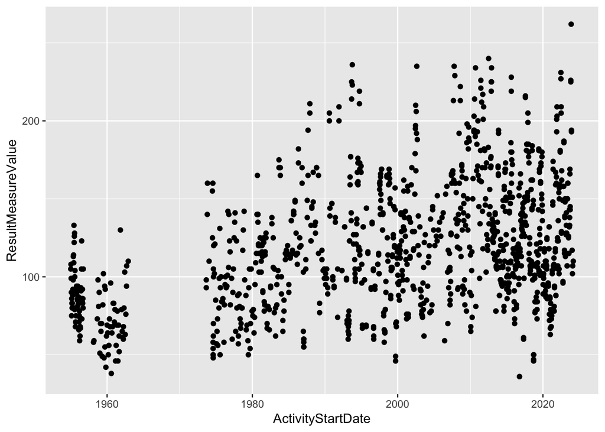

```r
plot_5 <- ggplot(data = qw_data, aes(x = ActivityStartDate, y = ResultMeasureValue)) +
  geom_point()

plot_5
```

```r
site <- "02105769"

qw_data <- readWQPqw(paste0("USGS-", site),
                     c("Specific conductance"))
```

[output not shown]

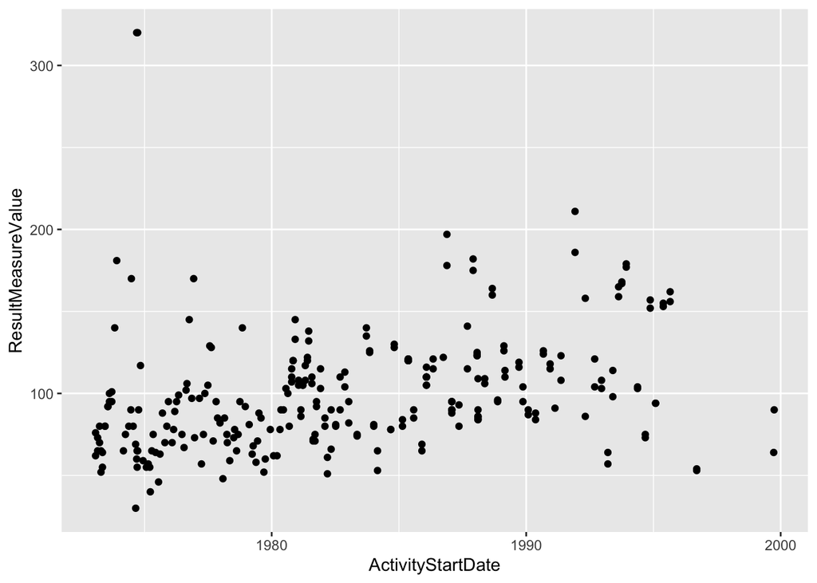

```r
plot_6 <- ggplot(data = qw_data, aes(x = ActivityStartDate, y = ResultMeasureValue)) +
  geom_point()

plot_6
```

```r
site <- "02105524"

qw_data <- readWQPqw(paste0("USGS-", site),
                     c("Specific conductance"))
```

[output not shown]

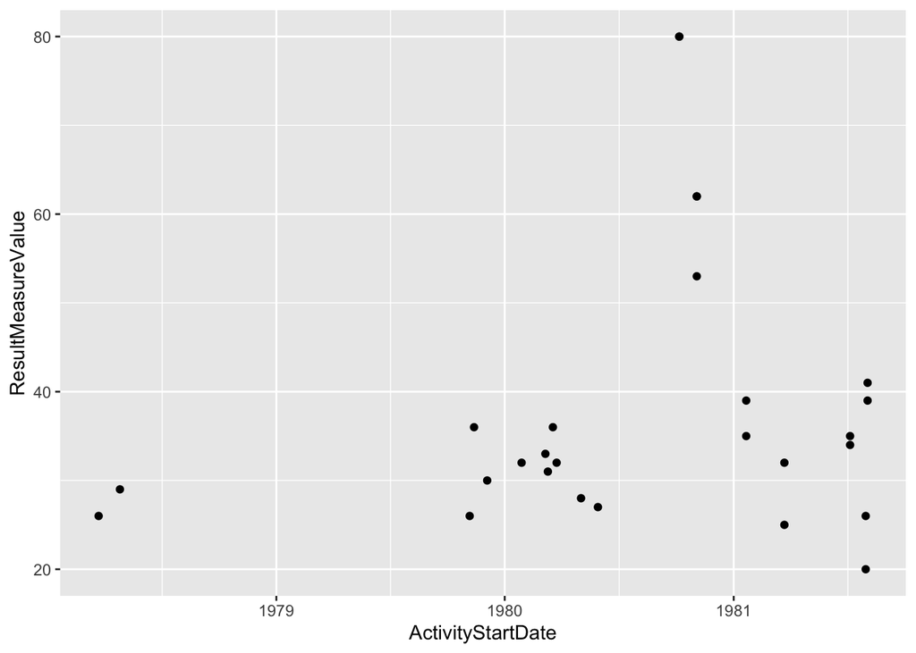

```r
plot_7 <- ggplot(data = qw_data, aes(x = ActivityStartDate, y = ResultMeasureValue)) +
  geom_point()

plot_7
```

```r
site <- "02098198"

qw_data <- readWQPqw(paste0("USGS-", site),
                     c("Specific conductance"))
```

[output not shown]

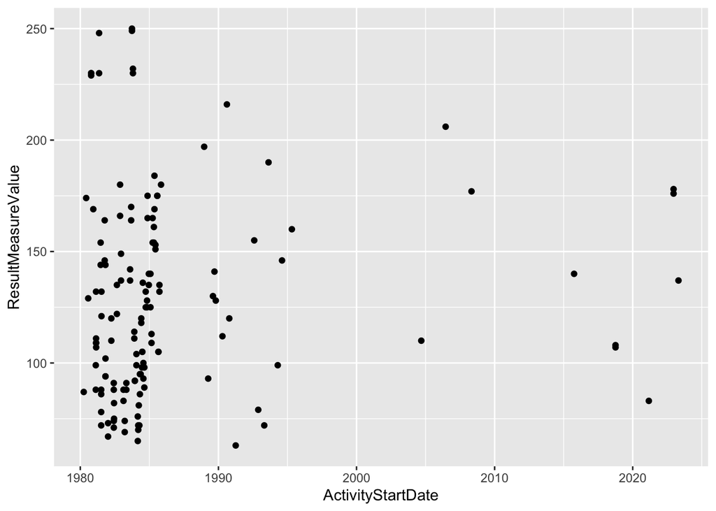

```r
plot_8 <- ggplot(data = qw_data, aes(x = ActivityStartDate, y = ResultMeasureValue)) +
  geom_point()

plot_8
```

```r
site <- "02129000"

qw_data <- readWQPqw(paste0("USGS-", site),
                     c("Specific conductance"))
```

[output not shown]

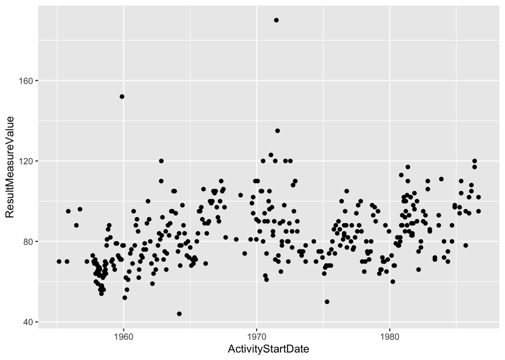

```r
plot_9 <- ggplot(data = qw_data, aes(x = ActivityStartDate, y = ResultMeasureValue)) +
  geom_point()

plot_9
```

```r
site <- "03460000"

qw_data <- readWQPqw(paste0("USGS-", site),
                     c("Specific conductance"))
```

[output not shown]

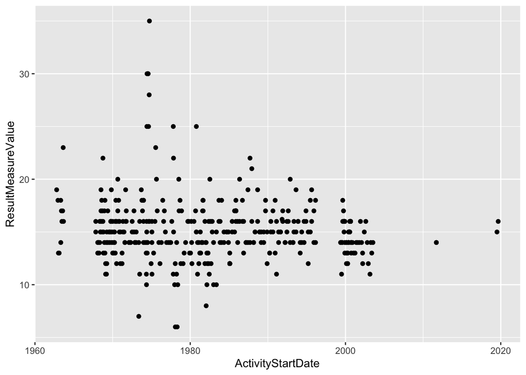

```r
plot_10 <- ggplot(data = qw_data, aes(x = ActivityStartDate, y = ResultMeasureValue)) +
  geom_point()

plot_10
```